# File 1- EDA

Barry DeCicco

3/14/2021

## What this is about

This file covers the initial ‘poking and prodding’ of a data set (in R, a ‘data frame’, or ‘tibble’).

The initial goals are to figure out the general nature of the data set. The detailed statistical analyses come later.

The classic situations are: 1. You’ve imported a data set from somewhere else, and you want to see if the import process messed anything up, and 2. Somebody handed you an R data frame (already imported), and you want to get an overall sense of what you are dealing with.

#### Library

This file will also serve as a collection of several different methods, which do overlapping tasks. In some cases, the choice of method is based on what gives the nicest looking output.

## Libraries and data sets

The first step is to load the packages and data sets used in this file:

- **janitor**,
- **kableExtra**
- **inspectdf**
- **skimr**
- **magrittr**
- **gridExtra** # for a grid layouts
- **DataExplorer**
- **htmltools** # for inspectdf plots
- **tidyverse**

#### Data sets:

- **mtcars**,
- **mpg**
- **iris**

## Why Do Exploratory Data Analysis?

- **Make Sure that the import went well**
- **Find out what data you have - by column**
- **Find out what data you have - by row**

**The first point is not emphasized, but should be - when importing data sets, it’s really easy to have things not be understood correctly by R, resulting in numeric/date variables being read in as strings, or missing value codes not being understood.**

#### Make Sure that the import went well.

- **Is the created object a data frame?**
- **What are the row/column counts? (what did you expect?)**
- **What are the column types? (Numeric/Character/Dates as expected)**

```r
print(class(mpg))
```

```
## [1] "tbl_df"     "tbl"        "data.frame"
```

```r
print(dim(mpg))
```

```
## [1] 234  11
```

Find out what the columns are like:

```r
names(mpg)
```

```
##  [1] "manufacturer" "model"        "displ"        "year"         "cyl"
##  [6] "trans"        "drv"          "cty"          "hwy"          "fl"
## [11] "class"
```

```r
str(mpg)
```

```
## tibble [234 x 11] (S3: tbl_df/tbl/data.frame)
##  $ manufacturer: chr [1:234] "audi" "audi" "audi" "audi" ...
##  $ model       : chr [1:234] "a4" "a4" "a4" "a4" ...
##  $ displ       : num [1:234] 1.8 1.8 2 2 2.8 2.8 3.1 1.8 1.8 2 ...
##  $ year        : int [1:234] 1999 1999 2008 2008 1999 1999 2008 1999 1999 2008 ...
##  $ cyl         : int [1:234] 4 4 4 4 6 6 6 4 4 4 ...
##  $ trans       : chr [1:234] "auto(l5)" "manual(m5)" "manual(m6)" "auto(av)" ...
##  $ drv         : chr [1:234] "f" "f" "f" "f" ...
##  $ cty         : int [1:234] 18 21 20 21 16 18 18 18 16 20 ...
##  $ hwy         : int [1:234] 29 29 31 30 26 26 27 26 25 28 ...
##  $ fl          : chr [1:234] "p" "p" "p" "p" ...
##  $ class       : chr [1:234] "compact" "compact" "compact" "compact" ...
```

Glimpse: use the glimpse() command to get another look at the data set. This is more compact than str(), but with less data.

```r
glimpse(mpg)
```

```
## Rows: 234
## Columns: 11
## $ manufacturer <chr> "audi", "audi", "audi", "audi", "audi", "audi", "audi"...
## $ model        <chr> "a4", "a4", "a4", "a4", "a4", "a4", "a4", "a4 quattro"...
## $ displ        <dbl> 1.8, 1.8, 2.0, 2.0, 2.8, 2.8, 3.1, 1.8, 1.8, 2.0, 2.0,...
## $ year         <int> 1999, 1999, 2008, 2008, 1999, 1999, 2008, 1999, 1999, ...
## $ cyl          <int> 4, 4, 4, 4, 6, 6, 6, 4, 4, 4, 4, 6, 6, 6, 6, 6, 6, 8, ...
## $ trans        <chr> "auto(l5)", "manual(m5)", "manual(m6)", "auto(av)", "a...
## $ drv          <chr> "f", "f", "f", "f", "f", "f", "f", "4", "4", "4", "4",...
## $ cty          <int> 18, 21, 20, 21, 16, 18, 18, 18, 16, 20, 19, 15, 17, 17...
## $ hwy          <int> 29, 29, 31, 30, 26, 26, 27, 26, 25, 28, 27, 25, 25, 25...
## $ fl           <chr> "p", "p", "p", "p", "p", "p", "p", "p", "p", "p", "p",...
## $ class        <chr> "compact", "compact", "compact", "compact", "compact",...
```

Get a list of the types (classes) of each column in a nicer arrangement:

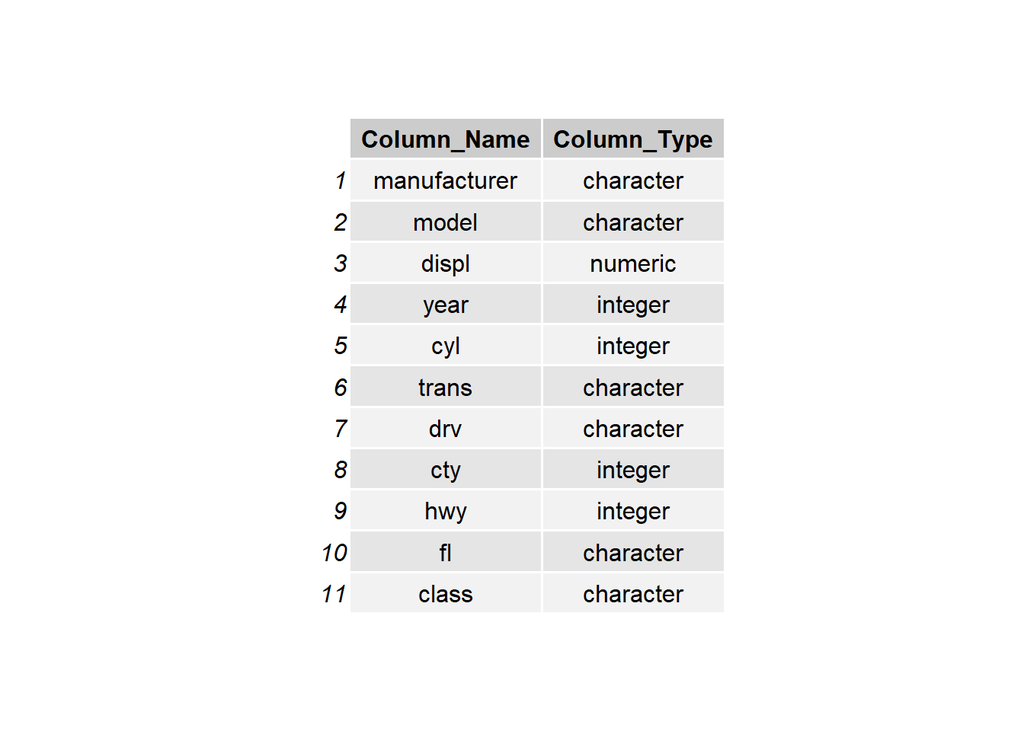

```r
options(width = 80)

# From:  https://stackoverflow.com/questions/40306280/how-to-transpose-a-dataframe-in-tidyverse

df_column_types <- lapply(mpg, class) %>%
  as.data.frame() %>%
  tibble::rownames_to_column() %>%
  pivot_longer(-rowname) %>%
  pivot_wider(names_from=rowname, values_from=value) %>%
  rename("Column_Name" = "name", "Column_Type" = "1")


grid.table(df_column_types)
```

#### Summaries within columns

When you want to see things by column: 1. Summary statistics for numeric data. 2. How many unique values are in each column? 3. How many missing values are in each column?

```r
summary_df <- summary(mpg)  %>% as.data.frame()

summary_df
```

```
##    Var1         Var2               Freq
## 1       manufacturer Length:234
## 2       manufacturer Class :character
## 3       manufacturer Mode  :character
## 4       manufacturer               <NA>
## 5       manufacturer               <NA>
## 6       manufacturer               <NA>
## 7              model Length:234
## 8              model Class :character
## 9              model Mode  :character
## 10             model               <NA>
## 11             model               <NA>
## 12             model               <NA>
## 13             displ    Min.   :1.600
## 14             displ    1st Qu.:2.400
```

[output cut: 52 more lines]

Unique values by column - the lapply function will go over the columns of the first argument (the data frame ‘mpg’) and apply the function given in the second argument (‘unique’)

```r
 lapply(mpg, unique)
```

```
## $manufacturer
##  [1] "audi"       "chevrolet"  "dodge"      "ford"       "honda"
##  [6] "hyundai"    "jeep"       "land rover" "lincoln"    "mercury"
## [11] "nissan"     "pontiac"    "subaru"     "toyota"     "volkswagen"
##
## $model
##  [1] "a4"                     "a4 quattro"             "a6 quattro"
##  [4] "c1500 suburban 2wd"     "corvette"               "k1500 tahoe 4wd"
##  [7] "malibu"                 "caravan 2wd"            "dakota pickup 4wd"
## [10] "durango 4wd"            "ram 1500 pickup 4wd"    "expedition 2wd"
## [13] "explorer 4wd"           "f150 pickup 4wd"        "mustang"
## [16] "civic"                  "sonata"                 "tiburon"
## [19] "grand cherokee 4wd"     "range rover"            "navigator 2wd"
## [22] "mountaineer 4wd"        "altima"                 "maxima"
## [25] "pathfinder 4wd"         "grand prix"             "forester awd"
## [28] "impreza awd"            "4runner 4wd"            "camry"
## [31] "camry solara"           "corolla"                "land cruiser wagon 4wd"
## [34] "toyota tacoma 4wd"      "gti"                    "jetta"
## [37] "new beetle"             "passat"
##
## $displ
##  [1] 1.8 2.0 2.8 3.1 4.2 5.3 5.7 6.0 6.2 7.0 6.5 2.4 3.5 3.6 3.0 3.3 3.8 4.0 3.7
## [20] 3.9 4.7 5.2 5.9 4.6 5.4 5.0 1.6 2.5 2.7 6.1 4.4 5.6 2.2 3.4 1.9
##
## $year
## [1] 1999 2008
##
## $cyl
## [1] 4 6 8 5
##
## $trans
##  [1] "auto(l5)"   "manual(m5)" "manual(m6)" "auto(av)"   "auto(s6)"
##  [6] "auto(l4)"   "auto(l3)"   "auto(l6)"   "auto(s5)"   "auto(s4)"
##
## $drv
## [1] "f" "4" "r"
##
## $cty
##  [1] 18 21 20 16 19 15 17 14 11 13 12 22  9 28 24 25 23 26 33 35 29
##
## $hwy
##  [1] 29 31 30 26 27 25 28 24 23 20 15 17 19 14 22 21 18 12 16 33 32 34 36 35 37
## [26] 44 41
##
## $fl
## [1] "p" "r" "e" "d" "c"
##
## $class
## [1] "compact"    "midsize"    "suv"        "2seater"    "minivan"
## [6] "pickup"     "subcompact"
```

Missing values - you want to know how many missing values are in each column.

R uses the ‘NA’ symbol to mean ‘missing’. It is not the actual letters ‘NA’, but rather a symbol. This method uses the package ‘purr’, from the tidyverse, to ‘map’ a function across the columns.

The function used is an improvised function, which applies the standard function ‘is.na()’ to each element of the column, then sums them. is.na() returns TRUE/FALSE for each elment; when they are summed: TRUE is evaluated as 1; FALSE is evaluated as 0.

```r
# from:  https://sebastiansauer.github.io/sum-isna/   'Way 2: using purrr:map'

missing_counts_by_column <- map(mpg,
                           ~sum(is.na(.))) %>%
              as.data.frame()

missing_counts_by_column
```

```
##   manufacturer model displ year cyl trans drv cty hwy fl class
## 1            0     0     0    0   0     0   0   0   0  0     0
```

Counting missing values by row. Sometimes you want to track missing values by row of the data frame.

this uses the apply function, with a ‘MARGIN’ argument to cause the application to be by rows. ‘MARGIN=2’ would apply the function by columns, producing a by-column count as in the previous example.

```r
# from:  https://sebastiansauer.github.io/sum-isna/   'Way 4: Counting NAs rowwise using apply'

missing_counts_by_row <-apply(mtcars,
              MARGIN = 1,
              function(x) sum(is.na(x)))   %>%
          as.data.frame()


missing_counts_by_row
```

```
##                     .
## Mazda RX4           0
## Mazda RX4 Wag       0
## Datsun 710          0
## Hornet 4 Drive      0
## Hornet Sportabout   0
## Valiant             0
## Duster 360          0
## Merc 240D           0
## Merc 230            0
## Merc 280            0
## Merc 280C           0
## Merc 450SE          0
## Merc 450SL          0
## Merc 450SLC         0
## Cadillac Fleetwood  0
## Lincoln Continental 0
## Chrysler Imperial   0
## Fiat 128            0
## Honda Civic         0
## Toyota Corolla      0
## Toyota Corona       0
## Dodge Challenger    0
## AMC Javelin         0
## Camaro Z28          0
## Pontiac Firebird    0
## Fiat X1-9           0
## Porsche 914-2       0
## Lotus Europa        0
## Ford Pantera L      0
## Ferrari Dino        0
## Maserati Bora       0
## Volvo 142E          0
```

## Using packages for EDA

### skimr

(https://cran.r-project.org/web/packages/skimr/vignettes/skimr.html)

This is the first pacakage that we’ll look at. Think of skimr as a collection of useful functions. One of those is to produce summaries. Skimr produces different summaries for character and numeric columns, so its convenient to run it separately. We will use functions from the dplyr package to split the mpg data sets into the subsets of character and numeric columns, and run skimr on each.

Skimr selects the appropriate summaries for character variables:

```r
 mpg %>%
  dplyr::select_if(is.character) %>%
  skim()
```

Data summary

| Name | Piped data |
| --- | --- |
| Number of rows | 234 |
| Number of columns | 6 |
| _______________________ |  |
| Column type frequency: |  |
| character | 6 |
| ________________________ |  |
| Group variables | None |

**Variable type: character**

| skim_variable | n_missing | complete_rate | min | max | empty | n_unique | whitespace |
| --- | --- | --- | --- | --- | --- | --- | --- |
| manufacturer | 0 | 1 | 4 | 10 | 0 | 15 | 0 |
| model | 0 | 1 | 2 | 22 | 0 | 38 | 0 |
| trans | 0 | 1 | 8 | 10 | 0 | 10 | 0 |
| drv | 0 | 1 | 1 | 1 | 0 | 3 | 0 |
| fl | 0 | 1 | 1 | 1 | 0 | 5 | 0 |
| class | 0 | 1 | 3 | 10 | 0 | 7 | 0 |

Skimr selects the appropriate summaries for numeric variables:

```r
mpg %>%
  dplyr::select_if(is.numeric) %>%
  skim()
```

Data summary

| Name | Piped data |
| --- | --- |
| Number of rows | 234 |
| Number of columns | 5 |
| _______________________ |  |
| Column type frequency: |  |
| numeric | 5 |
| ________________________ |  |
| Group variables | None |

**Variable type: numeric**

| skim_variable | n_missing | complete_rate | mean | sd | p0 | p25 | p50 | p75 | p100 | hist |
| --- | --- | --- | --- | --- | --- | --- | --- | --- | --- | --- |
| displ | 0 | 1 | 3.47 | 1.29 | 1.6 | 2.4 | 3.3 | 4.6 | 7 | ▇▆▆▃▁ |
| year | 0 | 1 | 2003.50 | 4.51 | 1999.0 | 1999.0 | 2003.5 | 2008.0 | 2008 | ▇▁▁▁▇ |
| cyl | 0 | 1 | 5.89 | 1.61 | 4.0 | 4.0 | 6.0 | 8.0 | 8 | ▇▁▇▁▇ |
| cty | 0 | 1 | 16.86 | 4.26 | 9.0 | 14.0 | 17.0 | 19.0 | 35 | ▆▇▃▁▁ |
| hwy | 0 | 1 | 23.44 | 5.95 | 12.0 | 18.0 | 24.0 | 27.0 | 44 | ▅▅▇▁▁ |

```r
 mpg %>%
  dplyr::select_if(is.character) %>%
  skim()
```

Data summary

| Name | Piped data |
| --- | --- |
| Number of rows | 234 |
| Number of columns | 6 |
| _______________________ |  |
| Column type frequency: |  |
| character | 6 |
| ________________________ |  |
| Group variables | None |

**Variable type: character**

| skim_variable | n_missing | complete_rate | min | max | empty | n_unique | whitespace |
| --- | --- | --- | --- | --- | --- | --- | --- |
| manufacturer | 0 | 1 | 4 | 10 | 0 | 15 | 0 |
| model | 0 | 1 | 2 | 22 | 0 | 38 | 0 |
| trans | 0 | 1 | 8 | 10 | 0 | 10 | 0 |
| drv | 0 | 1 | 1 | 1 | 0 | 3 | 0 |
| fl | 0 | 1 | 1 | 1 | 0 | 5 | 0 |
| class | 0 | 1 | 3 | 10 | 0 | 7 | 0 |

#### DataExplorer

(https://www.littlemissdata.com/blog/simple-eda)

This package runs a full report, in a new html document, covering a long list of items.

```r
DataExplorer::create_report(mpg)
```

```
##
##
## processing file: report.rmd
```

[output not shown]

[output not shown]

[output not shown]

[output not shown]

[output not shown]

[output not shown]

[output not shown]

[output not shown]

```
## output file: C:/Users/decicco1/OneDrive - Michigan State University/CSTATRedirects/Documents/R Studio Projects/EDA_Descriptives_Tables/report.knit.md
```

[output not shown]

```
##
## Output created: report.html
```

#### inspectdf

(https://www.rdocumentation.org/packages/inspectdf/versions/0.0.9. https://www.littlemissdata.com/blog/inspectdf) https://www.littlemissdata.com/blog/simple-eda

This package, like skimr, has a collection of functions which specialize in one task:

- inspect_na: Summary and comparison of the rate of missingness across dataframe columns
- inspect_imb: Summary and comparison of the most common levels in categorical columns
- inspect_cat: Summary and comparison of the levels in categorical columns
- show_plot Simple graphical inspection of dataframe summaries
- inspect_types: Summary and comparison of column types
- inspect_num: Summary and comparison of numeric columns

Only two functions will be illustrated: inspect_cat() and inspect_ibm(), both of which examine categorical variables.

```r
inspectdf::inspect_cat(mpg)
```

```
## # A tibble: 6 x 5
##   col_name       cnt common      common_pcnt levels
##   <chr>        <int> <chr>             <dbl> <named list>
## 1 class            7 suv               26.5  <tibble [7 x 3]>
## 2 drv              3 f                 45.3  <tibble [3 x 3]>
## 3 fl               5 r                 71.8  <tibble [5 x 3]>
## 4 manufacturer    15 dodge             15.8  <tibble [15 x 3]>
## 5 model           38 caravan 2wd        4.70 <tibble [38 x 3]>
## 6 trans           10 auto(l4)          35.5  <tibble [10 x 3]>
```

```r
inspectdf::inspect_imb(mpg)
```

```
## # A tibble: 6 x 4
##   col_name     value        pcnt   cnt
##   <chr>        <chr>       <dbl> <int>
## 1 fl           r           71.8    168
## 2 drv          f           45.3    106
## 3 trans        auto(l4)    35.5     83
## 4 class        suv         26.5     62
## 5 manufacturer dodge       15.8     37
## 6 model        caravan 2wd  4.70    11
```